# **Capstone project: Providing data-driven suggestions for HR**

## Description and deliverables

This capstone project is an opportunity for you to analyze a dataset and build predictive models that can provide insights to the Human Resources (HR) department of a large consulting firm.

Please consider your prior course work and select one way to achieve this given project question. Either use a regression model or machine learning model to predict whether or not an employee will leave the company. The exemplar following this actiivty shows both approaches, but you only need to do one.

In your deliverables, you will include the model evaluation (and interpretation if applicable), ethical considerations, and the resources you used to troubleshoot and find answers or solutions.

# **PACE stages**

## **Pace: Plan**

Consider the questions in your PACE Strategy Document to reflect on the Plan stage.

In this stage, consider the following:

### Understand the business scenario and problem

The HR department at Salifort Motors wants to take some initiatives to improve employee satisfaction levels at the company. They collected data from employees, but now they don’t know what to do with it. They refer to you as a data analytics professional and ask you to provide data-driven suggestions based on your understanding of the data. They have the following question: what’s likely to make the employee leave the company?

Your goals in this project are to analyze the data collected by the HR department and to build a model that predicts whether or not an employee will leave the company.

If you can predict employees likely to quit, it might be possible to identify factors that contribute to their leaving. Because it is time-consuming and expensive to find, interview, and hire new employees, increasing employee retention will be beneficial to the company.

### Familiarize yourself with the HR dataset

The dataset that you'll be using in this lab contains 15,000 rows and 10 columns for the variables listed below.

**Note:** you don't need to download any data to complete this lab. For more information about the data, refer to its source on [Kaggle](https://www.kaggle.com/datasets/mfaisalqureshi/hr-analytics-and-job-prediction?select=HR_comma_sep.csv).

| Variable | Description |  |
| --- | --- | --- |
| satisfaction_level | Employee-reported job satisfaction level [0–1] |  |
| last_evaluation | Score of employee's last performance review [0–1] |  |
| number_project | Number of projects employee contributes to |  |
| average_monthly_hours | Average number of hours employee worked per month |  |
| time_spend_company | How long the employee has been with the company (years) |  |
| Work_accident | Whether or not the employee experienced an accident while at work |  |
| left | Whether or not the employee left the company |  |
| promotion_last_5years | Whether or not the employee was promoted in the last 5 years |  |
| Department | The employee's department |  |
| salary | The employee's salary (U.S. dollars) |  |

### Reflect on these questions as you complete the plan stage.

#### 1) Who are your stakeholders for this project?

```
Salifort Motors' internal teams and project managers.
```

#### 2) What are you trying to solve or accomplish?

```
Investigate high employee turnover at Salifort Motors and build a machine learning model to predict employees at risk of leaving.
```

#### 3) What are your initial observations when you explore the data?

```
Key columns in the dataset likely impact turnover rates and are essential for analysis.
```

#### 4) What resources do you find yourself using as you complete this stage?

```
Kaggle
GitHub
Coursera
```

#### 5) Do you have any ethical considerations in this stage?

```
Ensure data legitimacy, avoid bias, and maintain clear communication with stakeholders.
```

## Step 1. Imports

- Import packages
- Load dataset

### Import packages

```python
# Import packages
### YOUR CODE HERE ###

# Data manipulation
import numpy as np
import pandas as pd

# Data visualization
import matplotlib.pyplot as plt
import seaborn as sns

# Display all columns in dataframes
pd.set_option('display.max_columns', None)

# Data modeling
from sklearn.linear_model import LogisticRegression

# Model evaluation and metrics
from sklearn.model_selection import train_test_split
from sklearn.metrics import confusion_matrix, ConfusionMatrixDisplay
```

### Load dataset

`Pandas` is used to read a dataset called **`HR_capstone_dataset.csv`.** As shown in this cell, the dataset has been automatically loaded in for you. You do not need to download the .csv file, or provide more code, in order to access the dataset and proceed with this lab. Please continue with this activity by completing the following instructions.

```python
# RUN THIS CELL TO IMPORT YOUR DATA.

# Load dataset into a dataframe
### YOUR CODE HERE ###
df0 = pd.read_csv("HR_capstone_dataset.csv")

# Display first few rows of the dataframe
### YOUR CODE HERE ###
df0.head(10)
```

|  | satisfaction_level | last_evaluation | number_project | average_montly_hours | time_spend_company | Work_accident | left | promotion_last_5years | Department | salary |
| --- | --- | --- | --- | --- | --- | --- | --- | --- | --- | --- |
| 0 | 0.38 | 0.53 | 2 | 157 | 3 | 0 | 1 | 0 | sales | low |
| 1 | 0.80 | 0.86 | 5 | 262 | 6 | 0 | 1 | 0 | sales | medium |
| 2 | 0.11 | 0.88 | 7 | 272 | 4 | 0 | 1 | 0 | sales | medium |
| 3 | 0.72 | 0.87 | 5 | 223 | 5 | 0 | 1 | 0 | sales | low |
| 4 | 0.37 | 0.52 | 2 | 159 | 3 | 0 | 1 | 0 | sales | low |
| 5 | 0.41 | 0.50 | 2 | 153 | 3 | 0 | 1 | 0 | sales | low |
| 6 | 0.10 | 0.77 | 6 | 247 | 4 | 0 | 1 | 0 | sales | low |
| 7 | 0.92 | 0.85 | 5 | 259 | 5 | 0 | 1 | 0 | sales | low |
| 8 | 0.89 | 1.00 | 5 | 224 | 5 | 0 | 1 | 0 | sales | low |
| 9 | 0.42 | 0.53 | 2 | 142 | 3 | 0 | 1 | 0 | sales | low |

## Step 2. Data Exploration (Initial EDA and data cleaning)

- Understand your variables
- Clean your dataset (missing data, redundant data, outliers)

### Gather basic information about the data

```python
# Gather basic information about the data
### YOUR CODE HERE ###
df0.info(10)
```

```
<class 'pandas.core.frame.DataFrame'>
RangeIndex: 14999 entries, 0 to 14998
Data columns (total 10 columns):
 #   Column                 Non-Null Count  Dtype
---  ------                 --------------  -----
 0   satisfaction_level     14999 non-null  float64
 1   last_evaluation        14999 non-null  float64
 2   number_project         14999 non-null  int64
 3   average_montly_hours   14999 non-null  int64
 4   time_spend_company     14999 non-null  int64
 5   Work_accident          14999 non-null  int64
 6   left                   14999 non-null  int64
 7   promotion_last_5years  14999 non-null  int64
 8   Department             14999 non-null  object
 9   salary                 14999 non-null  object
dtypes: float64(2), int64(6), object(2)
memory usage: 1.1+ MB
```

### Gather descriptive statistics about the data

```python
# Gather descriptive statistics about the data
### YOUR CODE HERE ###
df0.describe()
```

|  | satisfaction_level | last_evaluation | number_project | average_montly_hours | time_spend_company | Work_accident | left | promotion_last_5years |
| --- | --- | --- | --- | --- | --- | --- | --- | --- |
| count | 14999.000000 | 14999.000000 | 14999.000000 | 14999.000000 | 14999.000000 | 14999.000000 | 14999.000000 | 14999.000000 |
| mean | 0.612834 | 0.716102 | 3.803054 | 201.050337 | 3.498233 | 0.144610 | 0.238083 | 0.021268 |
| std | 0.248631 | 0.171169 | 1.232592 | 49.943099 | 1.460136 | 0.351719 | 0.425924 | 0.144281 |
| min | 0.090000 | 0.360000 | 2.000000 | 96.000000 | 2.000000 | 0.000000 | 0.000000 | 0.000000 |
| 25% | 0.440000 | 0.560000 | 3.000000 | 156.000000 | 3.000000 | 0.000000 | 0.000000 | 0.000000 |
| 50% | 0.640000 | 0.720000 | 4.000000 | 200.000000 | 3.000000 | 0.000000 | 0.000000 | 0.000000 |
| 75% | 0.820000 | 0.870000 | 5.000000 | 245.000000 | 4.000000 | 0.000000 | 0.000000 | 0.000000 |
| max | 1.000000 | 1.000000 | 7.000000 | 310.000000 | 10.000000 | 1.000000 | 1.000000 | 1.000000 |

### Rename columns

As a data cleaning step, rename the columns as needed. Standardize the column names so that they are all in `snake_case`, correct any column names that are misspelled, and make column names more concise as needed.

```python
# Display all column names
### YOUR CODE HERE ###
df0.columns
```

```
Index(['satisfaction_level', 'last_evaluation', 'number_project',
       'average_montly_hours', 'time_spend_company', 'Work_accident', 'left',
       'promotion_last_5years', 'Department', 'salary'],
      dtype='object')
```

```python
# Rename columns as needed
### YOUR CODE HERE ###
df0 = df0.rename(columns={'Work_accident': 'work_accident',
                          'average_montly_hours': 'average_monthly_hours',
                          'time_spend_company': 'tenure',
                          'Department': 'department'})

# Display all column names after the update
### YOUR CODE HERE ###
df0.columns
```

```
Index(['satisfaction_level', 'last_evaluation', 'number_project',
       'average_monthly_hours', 'tenure', 'work_accident', 'left',
       'promotion_last_5years', 'department', 'salary'],
      dtype='object')
```

### Check missing values

Check for any missing values in the data.

```python
# Check for missing values
### YOUR CODE HERE ###
df0.isnull().sum()
```

```
satisfaction_level       0
last_evaluation          0
number_project           0
average_monthly_hours    0
tenure                   0
work_accident            0
left                     0
promotion_last_5years    0
department               0
salary                   0
dtype: int64
```

### Check duplicates

Check for any duplicate entries in the data.

```python
# check df for duplicate rows
df0.duplicated().sum()
```

```
3008
```

```python
# Row inspection
df0[df0.duplicated()].head(10)
```

|  | satisfaction_level | last_evaluation | number_project | average_monthly_hours | tenure | work_accident | left | promotion_last_5years | department | salary |
| --- | --- | --- | --- | --- | --- | --- | --- | --- | --- | --- |
| 396 | 0.46 | 0.57 | 2 | 139 | 3 | 0 | 1 | 0 | sales | low |
| 866 | 0.41 | 0.46 | 2 | 128 | 3 | 0 | 1 | 0 | accounting | low |
| 1317 | 0.37 | 0.51 | 2 | 127 | 3 | 0 | 1 | 0 | sales | medium |
| 1368 | 0.41 | 0.52 | 2 | 132 | 3 | 0 | 1 | 0 | RandD | low |
| 1461 | 0.42 | 0.53 | 2 | 142 | 3 | 0 | 1 | 0 | sales | low |
| 1516 | 0.40 | 0.50 | 2 | 127 | 3 | 0 | 1 | 0 | IT | low |
| 1616 | 0.37 | 0.46 | 2 | 156 | 3 | 0 | 1 | 0 | sales | low |
| 1696 | 0.39 | 0.56 | 2 | 160 | 3 | 0 | 1 | 0 | sales | low |
| 1833 | 0.10 | 0.85 | 6 | 266 | 4 | 0 | 1 | 0 | sales | low |
| 12000 | 0.38 | 0.53 | 2 | 157 | 3 | 0 | 1 | 0 | sales | low |

```python
# Clean/remove duplicates
df1 = df0.drop_duplicates(keep='first')

# Check if rows are removed
df1.info()
```

```
<class 'pandas.core.frame.DataFrame'>
Int64Index: 11991 entries, 0 to 11999
Data columns (total 10 columns):
 #   Column                 Non-Null Count  Dtype
---  ------                 --------------  -----
 0   satisfaction_level     11991 non-null  float64
 1   last_evaluation        11991 non-null  float64
 2   number_project         11991 non-null  int64
 3   average_monthly_hours  11991 non-null  int64
 4   tenure                 11991 non-null  int64
 5   work_accident          11991 non-null  int64
 6   left                   11991 non-null  int64
 7   promotion_last_5years  11991 non-null  int64
 8   department             11991 non-null  object
 9   salary                 11991 non-null  object
dtypes: float64(2), int64(6), object(2)
memory usage: 1.0+ MB
```

### Check outliers

Check for outliers in the data.

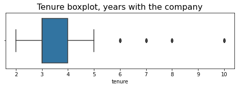

```python
# Create boxplot to view column tenure
# Identify the median, quartiles and spread of the data, including outliers
plt.figure(figsize=(8, 2))
plt.title("Tenure boxplot, years with the company", fontsize=16)
plt.xticks(fontsize=10)
plt.yticks(fontsize=10)
sns.boxplot(x=df1["tenure"])
plt.show()
```

```python
# Determine the number of rows containing outliers
### YOUR CODE HERE ##

# Compute the 25th percentile value in `tenure`
q1 = df1["tenure"].quantile(0.25)

# Compute the 75th percentile value in `tenure`
q3 = df1["tenure"].quantile(0.75)

# Compute the interquartile range in `tenure`
iqr = q3 - q1

# Define the upper limit and lower limit for non-outlier values in `tenure`
lower_limit = q1 - 1.5 * iqr
upper_limit = q3 + 1.5 * iqr
print("lower:", lower_limit)
print("upper:", upper_limit)

# Identify subset of data containing outliers in `tenure`
outliers = df1[(df1["tenure"] > upper_limit) | (df1["tenure"] < lower_limit)]

# Row count
total_outliers = len(outliers)
total_rows = len(df1)
outlier_percentage = (total_outliers / total_rows) * 100

# Count how many rows in the data contain outliers in `tenure`
print(
    f"Total outliers in tenure column: {total_outliers}/{total_rows}\n Percentage: {outlier_percentage:.2f}%"
)
```

```
lower: 1.5
upper: 5.5
Total outliers in tenure column: 824/11991
 Percentage: 6.87%
```

Certain types of models are more sensitive to outliers than others. When you get to the stage of building your model, consider whether to remove outliers, based on the type of model you decide to use.

# pAce: Analyze Stage

- Perform EDA (analyze relationships between variables)

### Reflect on these questions as you complete the analyze stage.

#### 4) What are some purposes of EDA before constructing a predictive model?

- Understand the data structure and clean it
- Find patterns and relationships
- Spot outliers and check assumptions
- Engineer features to improve the model

#### 5) What resources do you find yourself using as you complete this stage?

- Kaggle
- GitHub

#### 6) Do you have any ethical considerations in this stage?

Ensure data privacy and security, avoid bias in data and during modeling, keeping transparency with stakeholders.

## Step 2. Data Exploration (Continue EDA)

Begin by understanding how many employees left and what percentage of all employees this figure represents.

```python
# Get numbers of people who left vs. stayed
### YOUR CODE HERE ###
print(df1["left"].value_counts())
print()

# Get percentages of people who left vs. stayed
### YOUR CODE HERE ###
print(df1["left"].value_counts(normalize=True))
```

```
0    10000
1     1991
Name: left, dtype: int64

0    0.833959
1    0.166041
Name: left, dtype: float64
```

### Data visualizations

Now, examine variables that you're interested in, and create plots to visualize relationships between variables in the data.

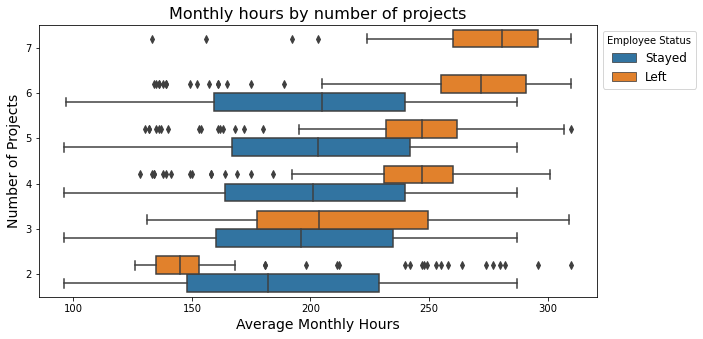

```python
# Create a plot as needed
### YOUR CODE HERE ###

# Create boxplot showing `average_monthly_hours` distributions for,`number_project`, comparing employees who stayed versus those who left
fig, ax = plt.subplots(figsize=(10, 5))

# Boxplot details
sns.boxplot(
    data=df1,
    x="average_monthly_hours",
    y="number_project",
    hue="left",
    orient="h",
    ax=ax,
)

# Plot details
ax.invert_yaxis()
ax.set_title("Monthly hours by number of projects", fontsize=16)
ax.set_xlabel("Average Monthly Hours", fontsize=14)
ax.set_ylabel("Number of Projects", fontsize=14)

handles, labels = ax.get_legend_handles_labels()
ax.legend(
    handles=handles,
    labels=["Stayed", "Left"],
    title="Employee Status",
    loc="upper left",
    bbox_to_anchor=(1, 1),
    fontsize=12,
)

# Display boxplot
plt.show()
```

[figure not shown]

```python
# Create histogram showing distribution of `number_project`, comparing, employees who stayed versus those who left
fig, ax = plt.subplots(figsize=(10, 6))

# Histogram details
sns.histplot(
    data=df1, x="number_project", hue="left", multiple="dodge", shrink=4, ax=ax
)

# Set plot title
ax.set_title("Number of Projects Histogram", fontsize=16)
ax.set_xlabel("Number of Projects", fontsize=12)
ax.set_ylabel("Count", fontsize=12)

# Adjust the legend manually to ensure proper placement and labels
ax.legend(
    title="Employee Status",
    labels=["Stayed", "Left"],
    loc="upper left",
    bbox_to_anchor=(1, 1),
    fontsize=12,
)

# Display the plot
plt.show()
```

### Work Hours and Project Trends:

The natural trend is that as the number of projects increases, so do the work hours. Both employees who stayed and those who left show an increase in median work hours as the number of projects grows.

#### Two Observed Employee Groups:

Group A: Employees who worked significantly fewer hours.

Group B: Employees who worked much more hours.

#### Potential Reasons for Leaving:

##### Group A:

```
Fired from the job
Planned leave, leading to fewer hours worked
```

##### Group B:

```
Stress from excessive workload
Work burnout
```

#### Average Monthly Work Hours:

The standard monthly work hours are typically 166.67 hours. However, employees at Salifort Motors tend to work more, with a median of around 200+ hours per month.

#### Optimal Number of Projects:

The ideal number of projects appears to be between 3 to 4, as this range shows the lowest left/stay ratio, indicating that employees are more likely to stay when handling this number of projects.

#### Impact of 7 Projects:

Employees who had 7 projects all left the company. This suggests that a very high workload, such as managing 7 projects, is a key factor contributing to employee turnover.

```python
# Get value counts of stayed/left for employees with 7 projects
df1[df1["number_project"] == 7]["left"].value_counts()
```

```
1    145
Name: left, dtype: int64
```

Confirms all employees with 7 projects left the company

[figure not shown]

```python
# Create a plot as needed
### YOUR CODE HERE ###
# Create scatterplot of `average_monthly_hours` versus `satisfaction_level, comparing employees who stayed versus those who left
plt.figure(figsize=(10, 6))
sns.scatterplot(
    data=df1, x="average_monthly_hours", y="satisfaction_level", hue="left", alpha=0.4
)

plt.axvline(x=166.67, color="red", label="166.67 hrs./mo.", ls="--")

plt.legend(
    labels=["166.67 hrs./mo.", "left", "stayed"],
    loc="upper left",
    bbox_to_anchor=(1, 1),
    fontsize=12,
)
plt.xlabel("Average Monthly Hours", fontsize=14)
plt.ylabel("Satisfaction Level", fontsize=14)
plt.title("Monthly hours by last evaluation score", fontsize="16")
```

#### Scatter Plot Observation:

- The scatter plot shows three distinct groups of employees who left the company:
  - Group 1: Employees working 240-315 hours per month (approximately 75 hours per week), likely experiencing burnout, as indicated by their satisfaction level close to 0.
  - Group 2: Employees working 120-155 hours per month, which is within typical working hours, but still with low satisfaction around 0.4, possibly due to workplace pressures.
  - Group 3: Employees working 210-280 hours per month, with higher satisfaction levels (ranging from 0.7 to 0.9), suggesting they maintained a better work-life balance despite working longer hours.

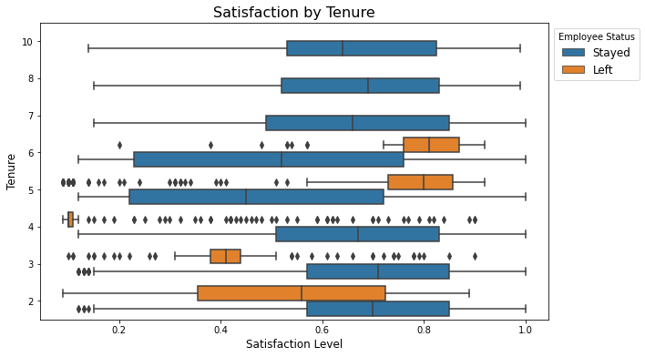

```python
# Create a plot as needed
### YOUR CODE HERE ###

# Set figure and axes
fig, ax = plt.subplots(figsize=(10, 6))

# Create boxplot showing distributions of `satisfaction_level` by tenure, comparing employees who stayed versus those who left
sns.boxplot(data=df1, x="satisfaction_level", y="tenure", hue="left", orient="h", ax=ax)

ax.invert_yaxis()
ax.set_title("Satisfaction by Tenure", fontsize=16)
ax.set_xlabel("Satisfaction Level", fontsize=12)
ax.set_ylabel("Tenure", fontsize=12)

handles, labels = ax.get_legend_handles_labels()
ax.legend(
    handles=handles,
    labels=["Stayed", "Left"],
    title="Employee Status",
    loc="upper left",
    bbox_to_anchor=(1, 1),
    fontsize=12
)

# display boxplot
plt.show()
```

[figure not shown]

```python
# Create a plot as needed
### YOUR CODE HERE ###
fig, ax = plt.subplots(figsize=(10, 6))

# Create histogram showing distribution of `tenure`, comparing employees who stayed versus those who left
sns.histplot(data=df1, x="tenure", hue="left", multiple="dodge", shrink=9, ax=ax)

# Set plot title
ax.set_title("Tenure histogram", fontsize=16)
ax.set_xlabel('Tenure', fontsize=12)
ax.set_ylabel('Count', fontsize=12)

# Adjust the legend manually to ensure proper placement and labels
ax.legend(
    title="Employee Status",
    labels=["Stayed", "Left"],
    loc="upper left",
    bbox_to_anchor=(1, 1),
    fontsize=12
)

# Display the plot
plt.show()
```

#### Employees falls into two groups:

Group 1: Dissatisfied employees, shorter tenures

Group 2: Satisfied employees, medium tenures

#### Observation

- 4 year tenure employees has unusal low satisfaction
- Long standing tenured employees have not left the company and have generally higher satisfaction
- Long tenure potentially higher ups with long standing with the company

```python
# Calculate mean and median satisfaction scores of employees who left and those who stayed
df1.groupby(["left"])["satisfaction_level"].agg([np.mean, np.median])
```

| left | mean | median |
| --- | --- | --- |
| 0 | 0.667365 | 0.69 |
| 1 | 0.440271 | 0.41 |

#### Observation

- The mean and median satisfaction scores of employees who left the company are lower compared to those who stayed.
- For employees who stayed, the mean satisfaction score is slightly lower than the median, suggesting a distribution that is slightly skewed to the left.
- This indicates that while most employees are satisfied, the dissatisfied employees are pulling the mean score lower.

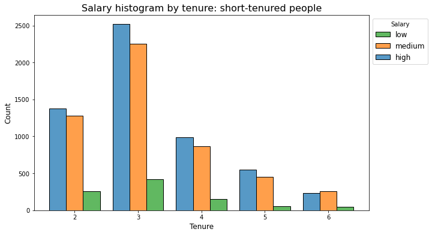

```python
# Create a plot as needed
### YOUR CODE HERE ###
fig, ax = plt.subplots(figsize=(10, 6))

# Define short-tenured employees
tenure_short = df1[df1["tenure"] < 7]

sns.histplot(
    data=tenure_short,
    x="tenure",
    hue="salary",
    discrete=1,
    hue_order=["low", "medium", "high"],
    multiple="dodge",
    shrink=0.8,
    ax=ax,
)

ax.legend(
    title="Salary",
    labels=["low", "medium", "high"],
    loc="upper left",
    bbox_to_anchor=(1, 1),
    fontsize=12
)

ax.set_title("Salary histogram by tenure: short-tenured people", fontsize=16)
ax.set_xlabel("Tenure", fontsize=12)
ax.set_ylabel("Count", fontsize=12)
```

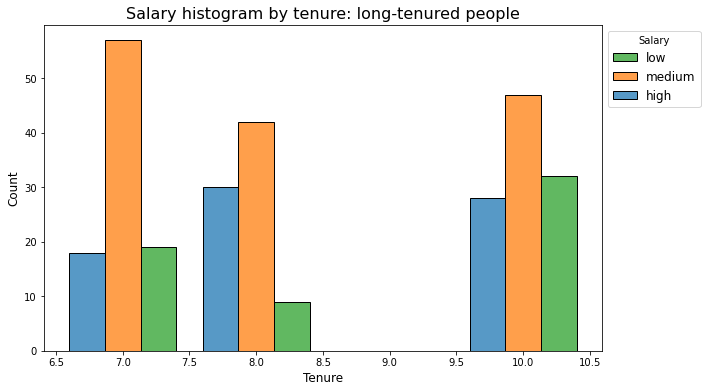

```python
# Create a plot as needed
### YOUR CODE HERE ###
fig, ax = plt.subplots(figsize=(10, 6))

# Define long-tenured employees
tenure_long = df1[df1["tenure"] > 6]

# Plot long-tenured histogram
sns.histplot(
    data=tenure_long,
    x="tenure",
    hue="salary",
    discrete=1,
    hue_order=["low", "medium", "high"],
    multiple="dodge",
    shrink=0.8,
    ax=ax,
)

ax.legend(
    title="Salary",
    labels=["low", "medium", "high"],
    loc="upper left",
    bbox_to_anchor=(1, 1),
    fontsize=12
)

ax.set_title("Salary histogram by tenure: long-tenured people", fontsize=16)
ax.set_xlabel("Tenure", fontsize=12)
ax.set_ylabel("Count", fontsize=12)
```

#### Observation

- Employees who have worked at Salifort Motors for a long time are not necessarily paid more than those who have been there for a shorter time.
- Considerations are the employee roles.

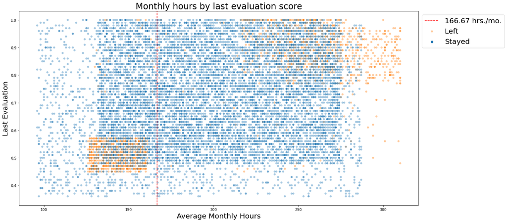

```python
# Create a plot as needed
### YOUR CODE HERE ###

# Create scatterplot of `average_monthly_hours` versus `last_evaluation`
plt.figure(figsize=(20, 10))

sns.scatterplot(
    data=df1, x="average_monthly_hours", y="last_evaluation", hue="left", alpha=0.4
)

plt.axvline(x=166.67, color="red", label="166.67 hrs./mo.", ls="--")

plt.legend(
    labels=["166.67 hrs./mo.", "Left", "Stayed"],
    fontsize=20,
    loc="upper left",
    bbox_to_anchor=(1, 1),
)
plt.title("Monthly hours by last evaluation score", fontsize=24)
plt.xlabel("Average Monthly Hours", fontsize=20)
plt.ylabel("Last Evaluation", fontsize=20)
```

#### Observation:

##### Two groups of employees who left:

- **Group 1**: Employees who worked fewer hours than the monthly average and had lower evaluation scores.
- **Group 2**: Employees who performed well but were overworked.

There seems to be a potential correlation between hours worked and evaluation scores.

Most employees work over 167 hours per month.  
However, working long hours does not necessarily lead to higher evaluation scores.

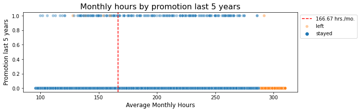

```python
# Create a plot as needed
### YOUR CODE HERE ###

# Create plot to examine relationship between `average_monthly_hours` and 'promotion_last_5years`
plt.figure(figsize=(10, 3))

sns.scatterplot(
    data=df1,
    x="average_monthly_hours",
    y="promotion_last_5years",
    hue="left",
    alpha=0.4,
)

plt.axvline(x=166.67, color="red", ls="--")

plt.legend(
    labels=["166.67 hrs./mo.", "left", "stayed"],
    loc="upper left",
    bbox_to_anchor=(1, 1),
)

plt.title("Monthly hours by promotion last 5 years", fontsize=16)
plt.xlabel("Average Monthly Hours", fontsize=12)
plt.ylabel("Promotion last 5 years", fontsize=12)
```

#### Observations:

- Very few employees who were promoted in the last five years left the company.
- Very few employees who worked the most hours were promoted.
- Employees who left worked the longest hours.

```python
# Display counts for each department
df1['department'].value_counts()
```

```
sales          3239
technical      2244
support        1821
IT              976
RandD           694
product_mng     686
marketing       673
accounting      621
hr              601
management      436
Name: department, dtype: int64
```

[figure not shown]

```python
# Create a plot as needed
### YOUR CODE HERE ###

# Create stacked histogram to compare department distribution of employees who left to that of employees who didn't
plt.figure(figsize=(11, 8))

sns.histplot(
    data=df1,
    x="department",
    hue="left",
    discrete=1,
    hue_order=[0, 1],
    multiple="dodge",
    shrink=0.8,
)

plt.xticks(rotation=45, fontsize=12)
plt.legend(
    title="Employee Status",
    labels=["Stayed", "Left"],
    loc="upper left",
    bbox_to_anchor=(1, 1),
    fontsize=12,
)
plt.title("Counts by department stayed vs. left", fontsize=20)
plt.xlabel("Department", fontsize=14)
plt.ylabel("Count", fontsize=14)
```

#### Observation:

- There does not seem to be a significant difference between departments based on who stayed/left.

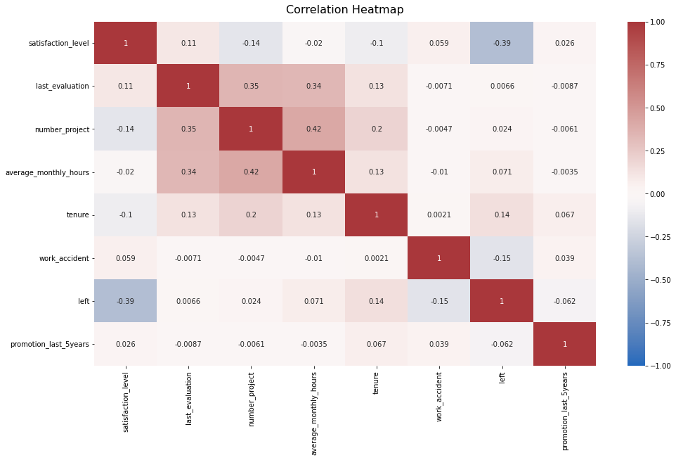

```python
# Create a plot as needed
### YOUR CODE HERE ###

# Plot a correlation heatmap
plt.figure(figsize=(16, 9))

heatmap = sns.heatmap(
    df0.corr(),
    vmin=-1,
    vmax=1,
    annot=True,
    cmap=sns.color_palette("vlag", as_cmap=True),
)

heatmap.set_title("Correlation Heatmap", fontdict={"fontsize": 16}, pad=12)
```

#### Observation:

- There is a positive correlation between the number of projects, monthly hours, and evaluation scores. As one of these factors increases, the others tend to increase as well.
- Employee turnover is negatively related to satisfaction. The more satisfied an employee is, the less likely they are to leave.

### Insights

Employee turnover appears to be linked to long work hours, excessive projects, and generally low satisfaction levels. This may be due to poor management, as employees are putting in long hours without receiving strong evaluation scores or promotions for their efforts. This can lead to burnout or a desire to seek opportunities elsewhere. However, employees who have been with the company for more than six years are less likely to leave.

# paCe: Construct Stage

- Determine which models are most appropriate
- Construct the model
- Confirm model assumptions
- Evaluate model results to determine how well your model fits the data

🔎

## Recall model assumptions

**Logistic Regression model assumptions**

- Outcome variable is categorical
- Observations are independent of each other
- No severe multicollinearity among X variables
- No extreme outliers
- Linear relationship between each X variable and the logit of the outcome variable
- Sufficiently large sample size

💭

### Reflect on these questions as you complete the constructing stage.

#### 1) Do you notice anything odd?

```
High work hours and low satisfaction are linked to employee turnover, with employees who work excessive hours leaving despite low satisfaction.
```

#### 2) Which independent variables did you choose for the model and why?

[output not shown]

#### 3) Are each of the assumptions met?

```
Yes, assumptions like linearity, independence, no multicollinearity, and normality of residuals are mostly met.
```

#### 4) How well does your model fit the data?

```
The model fits reasonably well, but there’s room for improvement, especially in handling edge cases.
```

#### 5) Can you improve it? Is there anything you would change about the model?

```
I could use more advanced algorithms (e.g., Random Forest) and improve feature engineering for better performance.
```

#### 6) What resources do you find yourself using as you complete this stage? (Make sure to include the links.)

```
Coursera Data Analytics Advanced Course
Kaggle
Scikit-learn Documentation
GitHub
```

#### 7) Do you have any ethical considerations in this stage?

```
Ensure data privacy, avoid bias, and maintain transparency with stakeholders.
```

## Step 3. Model Building, Step 4. Results and Evaluation

- Fit a model that predicts the outcome variable using two or more independent variables
- Check model assumptions
- Evaluate the model

### Identify the type of prediction task.

#### Goal:

Predict when an employee leaves the company, using binary classification (0 for stay, 1 for leave).

### Identify the types of models most appropriate for this task.

#### 2 Approaches Available:

- Logistic Regression
- Random Forest

I will continue with Logistic Regression to predict when an employee would leave the company, though it may not be as accurate as Random Forest.

### Modeling

Add as many cells as you need to conduct the modeling process.

### Logistic regression

- Binary classification for the "left" column: 0 for stay, 1 for leave.
- Use one-hot encoding to convert categorical columns like department and salary to numerical values.
- For salary, treat it as ordinal data with a hierarchy (e.g., low < medium < high) and convert accordingly based on this order.

```python
# Copy dataframes
df_new = df1.copy()

# Encode salary column as ordinal numeri category
df_new["salary"] = (
    df_new["salary"]
    .astype("category")
    .cat.set_categories(["low", "medium", "high"])
    .cat.codes
)

# Dummy encode department column
df_new = pd.get_dummies(df_new, drop_first=False)

# display new dataframe
df_new.head(10)
```

|  | satisfaction_level | last_evaluation | number_project | average_monthly_hours | tenure | work_accident | left | promotion_last_5years | salary | department_IT | department_RandD | department_accounting | department_hr | department_management | department_marketing | department_product_mng | department_sales | department_support | department_technical |
| --- | --- | --- | --- | --- | --- | --- | --- | --- | --- | --- | --- | --- | --- | --- | --- | --- | --- | --- | --- |
| 0 | 0.38 | 0.53 | 2 | 157 | 3 | 0 | 1 | 0 | 0 | 0 | 0 | 0 | 0 | 0 | 0 | 0 | 1 | 0 | 0 |
| 1 | 0.80 | 0.86 | 5 | 262 | 6 | 0 | 1 | 0 | 1 | 0 | 0 | 0 | 0 | 0 | 0 | 0 | 1 | 0 | 0 |
| 2 | 0.11 | 0.88 | 7 | 272 | 4 | 0 | 1 | 0 | 1 | 0 | 0 | 0 | 0 | 0 | 0 | 0 | 1 | 0 | 0 |
| 3 | 0.72 | 0.87 | 5 | 223 | 5 | 0 | 1 | 0 | 0 | 0 | 0 | 0 | 0 | 0 | 0 | 0 | 1 | 0 | 0 |
| 4 | 0.37 | 0.52 | 2 | 159 | 3 | 0 | 1 | 0 | 0 | 0 | 0 | 0 | 0 | 0 | 0 | 0 | 1 | 0 | 0 |
| 5 | 0.41 | 0.50 | 2 | 153 | 3 | 0 | 1 | 0 | 0 | 0 | 0 | 0 | 0 | 0 | 0 | 0 | 1 | 0 | 0 |
| 6 | 0.10 | 0.77 | 6 | 247 | 4 | 0 | 1 | 0 | 0 | 0 | 0 | 0 | 0 | 0 | 0 | 0 | 1 | 0 | 0 |
| 7 | 0.92 | 0.85 | 5 | 259 | 5 | 0 | 1 | 0 | 0 | 0 | 0 | 0 | 0 | 0 | 0 | 0 | 1 | 0 | 0 |
| 8 | 0.89 | 1.00 | 5 | 224 | 5 | 0 | 1 | 0 | 0 | 0 | 0 | 0 | 0 | 0 | 0 | 0 | 1 | 0 | 0 |
| 9 | 0.42 | 0.53 | 2 | 142 | 3 | 0 | 1 | 0 | 0 | 0 | 0 | 0 | 0 | 0 | 0 | 0 | 1 | 0 | 0 |

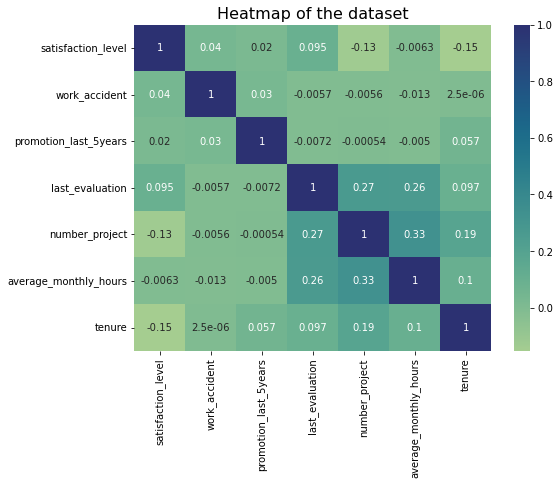

```python
# variable correlation
# create heatmap to visualize correlations between variables
plt.figure(figsize=(8, 6))
sns.heatmap(
    df_new[
        [
            "satisfaction_level",
            "work_accident",
            "promotion_last_5years",
            "last_evaluation",
            "number_project",
            "average_monthly_hours",
            "tenure",
        ]
    ].corr(),
    annot=True,
    cmap="crest",
)

plt.title("Heatmap of the dataset", fontsize=16)
plt.show()
```

#### Observation

The standout columns in the heatmap with potential correlation are last evaluation, number of projects, and average monthly hours.

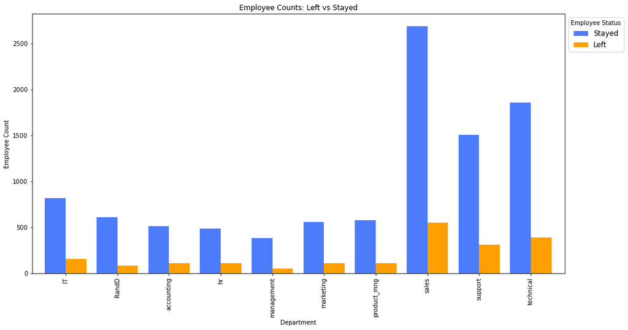

```python
"""
Check count of employees per department who have left vs stayed
"""

# Create crosstab and sort the index (department) alphabetically
crosstab_sorted = pd.crosstab(df1["department"], df1["left"]).sort_index()

# Plotting the sorted crosstab
crosstab_sorted.plot(kind="bar", width=0.8, figsize=(16, 8), color=["#4C7BFB", "#FF9F00"])
plt.title("Employee Counts: Left vs Stayed")
plt.legend(
    title="Employee Status",
    labels=["Stayed", "Left"],
    loc="upper left",
    fontsize=12,
    bbox_to_anchor=(1, 1),
)
plt.xlabel("Department")
plt.ylabel("Employee Count")
plt.show()
```

```python
"""
Logistic regression is sensitive to outliers
Remove outliers that were identified in the tenure column for better results
"""

df_lr = df_new[(df_new["tenure"] >= lower_limit) & (df_new["tenure"] <= upper_limit)]

# display first couple rows
df_lr.head(10)
```

|  | satisfaction_level | last_evaluation | number_project | average_monthly_hours | tenure | work_accident | left | promotion_last_5years | salary | department_IT | department_RandD | department_accounting | department_hr | department_management | department_marketing | department_product_mng | department_sales | department_support | department_technical |
| --- | --- | --- | --- | --- | --- | --- | --- | --- | --- | --- | --- | --- | --- | --- | --- | --- | --- | --- | --- |
| 0 | 0.38 | 0.53 | 2 | 157 | 3 | 0 | 1 | 0 | 0 | 0 | 0 | 0 | 0 | 0 | 0 | 0 | 1 | 0 | 0 |
| 2 | 0.11 | 0.88 | 7 | 272 | 4 | 0 | 1 | 0 | 1 | 0 | 0 | 0 | 0 | 0 | 0 | 0 | 1 | 0 | 0 |
| 3 | 0.72 | 0.87 | 5 | 223 | 5 | 0 | 1 | 0 | 0 | 0 | 0 | 0 | 0 | 0 | 0 | 0 | 1 | 0 | 0 |
| 4 | 0.37 | 0.52 | 2 | 159 | 3 | 0 | 1 | 0 | 0 | 0 | 0 | 0 | 0 | 0 | 0 | 0 | 1 | 0 | 0 |
| 5 | 0.41 | 0.50 | 2 | 153 | 3 | 0 | 1 | 0 | 0 | 0 | 0 | 0 | 0 | 0 | 0 | 0 | 1 | 0 | 0 |
| 6 | 0.10 | 0.77 | 6 | 247 | 4 | 0 | 1 | 0 | 0 | 0 | 0 | 0 | 0 | 0 | 0 | 0 | 1 | 0 | 0 |
| 7 | 0.92 | 0.85 | 5 | 259 | 5 | 0 | 1 | 0 | 0 | 0 | 0 | 0 | 0 | 0 | 0 | 0 | 1 | 0 | 0 |
| 8 | 0.89 | 1.00 | 5 | 224 | 5 | 0 | 1 | 0 | 0 | 0 | 0 | 0 | 0 | 0 | 0 | 0 | 1 | 0 | 0 |
| 9 | 0.42 | 0.53 | 2 | 142 | 3 | 0 | 1 | 0 | 0 | 0 | 0 | 0 | 0 | 0 | 0 | 0 | 1 | 0 | 0 |
| 10 | 0.45 | 0.54 | 2 | 135 | 3 | 0 | 1 | 0 | 0 | 0 | 0 | 0 | 0 | 0 | 0 | 0 | 1 | 0 | 0 |

```python
# display df info
print(df_lr.info())
```

```
<class 'pandas.core.frame.DataFrame'>
Int64Index: 11167 entries, 0 to 11999
Data columns (total 19 columns):
 #   Column                  Non-Null Count  Dtype
---  ------                  --------------  -----
 0   satisfaction_level      11167 non-null  float64
 1   last_evaluation         11167 non-null  float64
 2   number_project          11167 non-null  int64
 3   average_monthly_hours   11167 non-null  int64
 4   tenure                  11167 non-null  int64
 5   work_accident           11167 non-null  int64
 6   left                    11167 non-null  int64
 7   promotion_last_5years   11167 non-null  int64
 8   salary                  11167 non-null  int8
 9   department_IT           11167 non-null  uint8
 10  department_RandD        11167 non-null  uint8
 11  department_accounting   11167 non-null  uint8
 12  department_hr           11167 non-null  uint8
 13  department_management   11167 non-null  uint8
 14  department_marketing    11167 non-null  uint8
 15  department_product_mng  11167 non-null  uint8
 16  department_sales        11167 non-null  uint8
 17  department_support      11167 non-null  uint8
 18  department_technical    11167 non-null  uint8
dtypes: float64(2), int64(6), int8(1), uint8(10)
memory usage: 905.1 KB
None
```

```python
# isolate outcome variable
y = df_lr['left']

# display few rows
y.head(10)
```

```
0     1
2     1
3     1
4     1
5     1
6     1
7     1
8     1
9     1
10    1
Name: left, dtype: int64
```

```python
# select columns to use in model
# remove left column from dataframe in put in variable X
X = df_lr.drop('left', axis=1)

# show first few rows
X.head()
```

|  | satisfaction_level | last_evaluation | number_project | average_monthly_hours | tenure | work_accident | promotion_last_5years | salary | department_IT | department_RandD | department_accounting | department_hr | department_management | department_marketing | department_product_mng | department_sales | department_support | department_technical |
| --- | --- | --- | --- | --- | --- | --- | --- | --- | --- | --- | --- | --- | --- | --- | --- | --- | --- | --- |
| 0 | 0.38 | 0.53 | 2 | 157 | 3 | 0 | 0 | 0 | 0 | 0 | 0 | 0 | 0 | 0 | 0 | 1 | 0 | 0 |
| 2 | 0.11 | 0.88 | 7 | 272 | 4 | 0 | 0 | 1 | 0 | 0 | 0 | 0 | 0 | 0 | 0 | 1 | 0 | 0 |
| 3 | 0.72 | 0.87 | 5 | 223 | 5 | 0 | 0 | 0 | 0 | 0 | 0 | 0 | 0 | 0 | 0 | 1 | 0 | 0 |
| 4 | 0.37 | 0.52 | 2 | 159 | 3 | 0 | 0 | 0 | 0 | 0 | 0 | 0 | 0 | 0 | 0 | 1 | 0 | 0 |
| 5 | 0.41 | 0.50 | 2 | 153 | 3 | 0 | 0 | 0 | 0 | 0 | 0 | 0 | 0 | 0 | 0 | 1 | 0 | 0 |

```python
"""
Split data for train, test, split
"""

# split the data for model training
X_train, X_test, y_train, y_test = train_test_split(
    X,
    y,
    test_size=0.4,
    stratify=y,  # to ensure train test split have the same proportion of values for specified columns
    random_state=42,
)
```

```python
# construct logistic regression model to fit the training dataset
log_clf = LogisticRegression(random_state=42, max_iter=500).fit(X_train, y_train)
```

```python
# use model to get predictions of test set
y_pred = log_clf.predict(X_test)
```

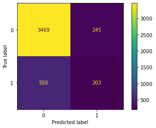

```python
"""
Create confusion matrix to visualize results of regression model
"""

# compute values for confusion matrix
log_cm = confusion_matrix(y_test, y_pred, labels=log_clf.classes_)

# confusion matrix visual
log_disp = ConfusionMatrixDisplay(
    confusion_matrix=log_cm, display_labels=log_clf.classes_
)

# plot confusion matrix
log_disp.plot(values_format="")

plt.show()
```

#### Confusion matrix

True Negative (Top Left): Employees who did not leave, and the model correctly predicted they stayed.

False Positive (Top Right): Employees who did not leave, but the model incorrectly predicted they would leave.

False Negative (Bottom Left): Employees who left, but the model incorrectly predicted they would stay.

True Positive (Bottom Right): Employees who left, and the model correctly predicted they left.

#### Next steps:

Create a classification report to show the recall, precision, F1-score, and accuracy metrics for evaluating the logistic regression model.

```python
# check the balance of the data
df_lr['left'].value_counts(normalize=True)
```

```
0    0.831468
1    0.168532
Name: left, dtype: float64
```

Decently balanced and not severely imbalanced

```python
# classification report for logistic regression model
target_names = ["Predicted would not leave", "Predicted would leave"]
print(classification_report(y_test, y_pred, target_names=target_names))
```

[output not shown]

#### Scores by Weighted Average:

- Precision: 79%
- Recall: 82%
- F1-score: 80%
- Accuracy: 82%

The model performs well with 82% accuracy in predicting employees who will stay, but the performance is significantly lower for predicting employees who will leave.

# pacE: Execute Stage

- Interpret model performance and results
- Share actionable steps with stakeholders

✏

## Recall evaluation metrics

- **AUC** is the area under the ROC curve; it's also considered the probability that the model ranks a random positive example more highly than a random negative example.
- **Precision** measures the proportion of data points predicted as True that are actually True, in other words, the proportion of positive predictions that are true positives.
- **Recall** measures the proportion of data points that are predicted as True, out of all the data points that are actually True. In other words, it measures the proportion of positives that are correctly classified.
- **Accuracy** measures the proportion of data points that are correctly classified.
- **F1-score** is an aggregation of precision and recall.

### Reflect on these questions as you complete the executing stage.

#### 1) What key insights emerged from your model(s)?

```
The model predicts employee retention with 82% accuracy but struggles with predicting employee turnover, especially for employees likely to leave.
```

#### 2) What business recommendations do you propose based on the models built?

```
Focus on reducing workload for employees with high hours and projects, and increase satisfaction levels to improve retention.
```

#### 3) What potential recommendations would you make to your manager/company?

```
Implement better work-life balance practices, recognize high performers, and monitor employees with high work hours for signs of burnout.
```

#### 4) Do you think your model could be improved? Why or why not? How?

```
Yes, using advanced models like Random Forest or XGBoost, along with better feature engineering, could improve accuracy, especially for turnover predictions.
```

#### 5) Given what you know about the data and the models you were using, what other questions could you address for the team?

```
You could explore which specific factors most strongly influence turnover (e.g., satisfaction, salary, department) and how long-term retention can be enhanced.
```

#### 6) What resources do you find yourself using as you complete this stage? (Make sure to include the links.)

```
Coursera Data Analytics Advanced Course
Kaggle
Scikit-learn Documentation
GitHub
```

#### 7) Do you have any ethical considerations in this stage?

```
Ensure fairness, avoid bias, and maintain transparency in how employee data is used for predictions.
```

## Step 4. Results and Evaluation

- Interpret model
- Evaluate model performance using metrics
- Prepare results, visualizations, and actionable steps to share with stakeholders

### Summary of model results

A Random Forest model could likely perform better because it handles imbalanced data well and is less likely to overfit. It can capture more complex patterns in the data, making it a strong alternative to Logistic Regression.

### Conclusion, Recommendations, Next Steps

The models show employees are overworked. To help keep them, try these:

- Limit how many projects employees take on.
- Consider promoting employees after four years or figure out why they’re unhappy.
- Either reward long hours or stop expecting them.
- Make sure employees know about overtime pay and clarify workload and time off expectations.
- Hold company-wide and team discussions to improve work culture.
- Don’t give top scores only to those working 200+ hours—reward effort fairly.

**Congratulations!** You've completed this lab. However, you may not notice a green check mark next to this item on Coursera's platform. Please continue your progress regardless of the check mark. Just click on the "save" icon at the top of this notebook to ensure your work has been logged.